# splines in mixed-effect models

Clay Ford

2022-04-13

## generate data

First generate data for 10 subjects (`g`) with 20 observations each (`n`). The `x` predictor ranges from 1:20. The x2 predictor is `x - 13` for `x > 13`. The `r`, `z0`, and `z1` vectors add noise. `z0` adds subject-specific noise to the intercept, `z1` adds subject-specific noise to the slope, and `r` adds noise to all observations. All noise is drawn from a Normal distribution with mean 0 and some fixed standard deviation, as is assumed by linear mixed-effect models.

```r
n <- 20
g <- 10
x <- rep(1:n, g)
id <- rep(1:g, each = n)
x2 <- ifelse((x - 13) > 0, (x - 13), 0)
set.seed(2)
r <- rnorm(length(x), sd = 0.8)
z0 <- rnorm(g, sd = 0.5)
z1 <- rnorm(g, sd = 0.2)
y <- (10 + z0[id]) + (-4 + z1[id])*x + (6 + z1[id])*x2 + r
d <- data.frame(id = factor(id), y, x)
```

## plot the data

Quick plot of the data with subjects color-coded.

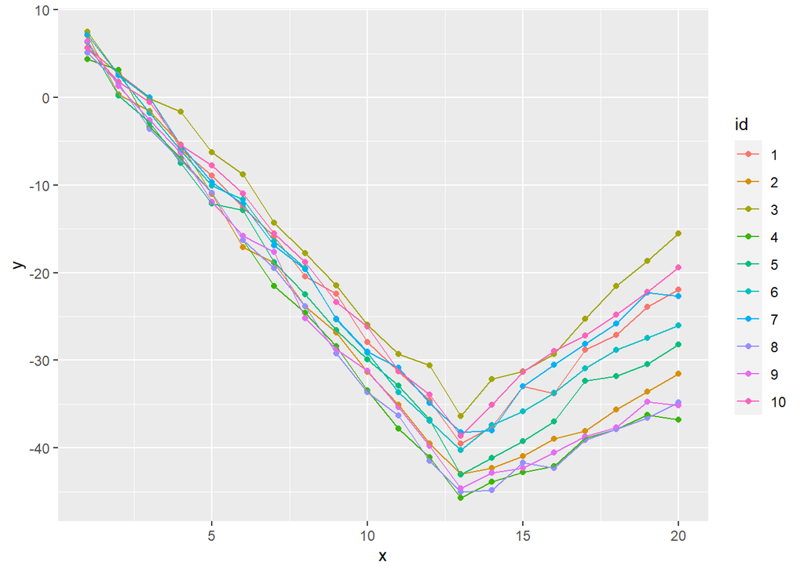

```r
library(ggplot2)
ggplot(d) +
  aes(x, y, color = id, group = id) +
  geom_point() +
  geom_line()
```

Quick plot of the data with a smooth trend line, which in this case is a loess curve.

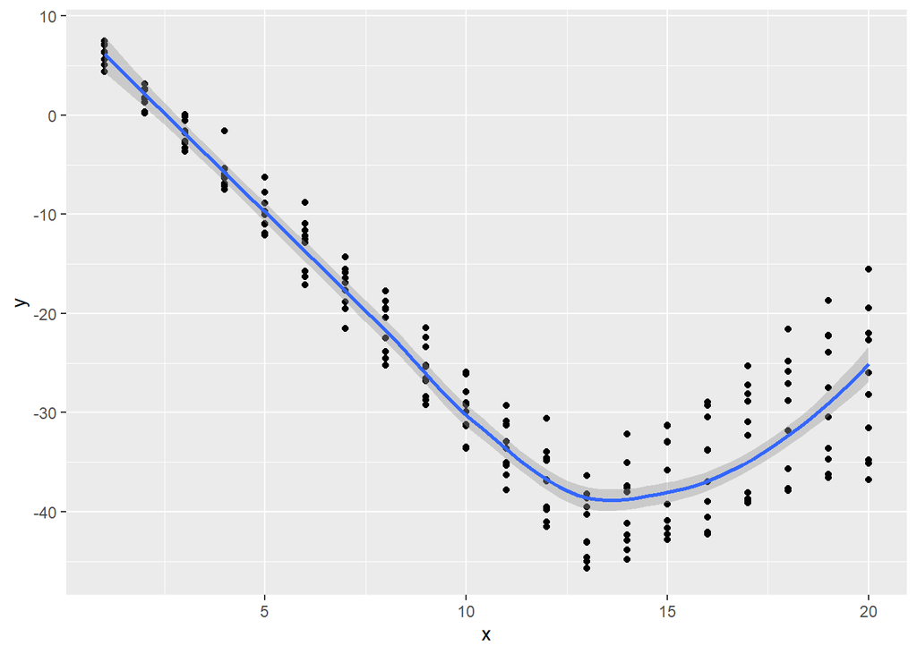

```r
ggplot(d) +
  aes(x, y) +
  geom_point() +
  geom_smooth()
```

## fit mixed-effect model

Below we fit a mixed-effect model that says the intercept and slope are conditional on subject: `(x|id)`. We also specify that `x` be modeled a cubic spline using the `ns` function from the splines package. `df=3` says we think the trajectory could change direction three times.

```r
library(lme4)
library(splines)
m1 <- lmer(y ~ ns(x, df = 3) + (x|id), data = d)
```

The summary output is all but impossible to interpret.

```r
summary(m1, corr = FALSE)
```

```
## Linear mixed model fit by REML ['lmerMod']
## Formula: y ~ ns(x, df = 3) + (x | id)
##    Data: d
##
## REML criterion at convergence: 772.7
##
## Scaled residuals:
##     Min      1Q  Median      3Q     Max
## -3.2604 -0.5278  0.0792  0.6657  2.3823
##
## Random effects:
##  Groups   Name        Variance Std.Dev. Corr
##  id       (Intercept) 0.03465  0.1862
##           x           0.10797  0.3286   -1.00
##  Residual             2.27348  1.5078
## Number of obs: 200, groups:  id, 10
##
## Fixed effects:
##                Estimate Std. Error t value
## (Intercept)      6.0940     0.3331   18.30
## ns(x, df = 3)1 -47.0004     1.2273  -38.30
## ns(x, df = 3)2 -58.9098     2.4632  -23.92
## ns(x, df = 3)3 -17.1021     1.6342  -10.46
## optimizer (nloptwrap) convergence code: 0 (OK)
## boundary (singular) fit: see help('isSingular')
```

So we can plot the smooth trend line and visually interpret.

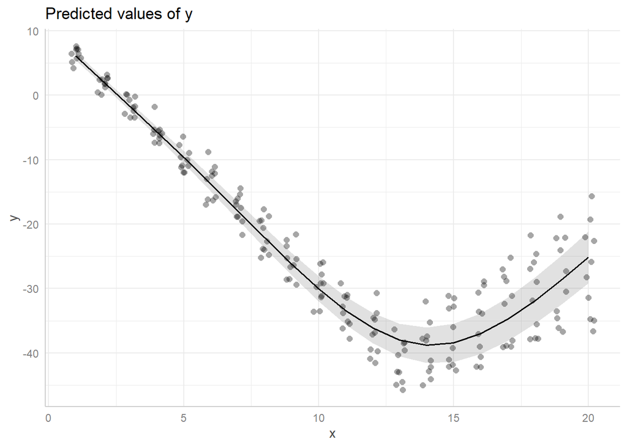

```r
library(ggeffects)
eff <- ggpredict(m1, "x[all]")
plot(eff, add.data = TRUE)
```

## piecewise spline

Here we fit something closer to the “correct” model. We use the **segmented** package to find the breakpoint. The **segmented** package does not work with lme4, but does (sort of) work with nlme, an older but still very powerful mixed-effect modeling package. Another quirk is that the variable with the breakpoint cannot have associated random effects, so we have to fit a random-intercept model (`~1|id`). First we fit the model using `lme` and then use `segmented.default` to estimate the breakpoint. The `npsi = 1` argument says we think there is one breakpoint.

```r
library(segmented)
library(nlme)
m2 <- lme(y ~ x, random = ~ 1|id, data = d)
sm1 <- segmented.default(m2, seg.Z = ~x, npsi = 1)
```

Use the `fixef` function to get the estimated slopes for each line. The estimated values are very close to the “true” values we used above to generate the data, -4 and 6.

```r
fixef(sm1)
```

```
## (Intercept)           x        U1.x      psi1.x
##   10.027966   -3.949946    6.050022    0.000000
```

The estimated breakpoint is extracted with the `confint.segmented` function. The true value of 13 falls well within the 95% CI.

```r
confint.segmented(sm1, "x", .coef=fixef(sm1))
```

```
##           Est. CI(95%).low CI(95%).up
## psi1.x 13.0328     12.8203    13.2454
```

We might report this as follows:

$$y = 10.03 + -3.95x \hspace{1cm} x \le
13.03$$

$$y = 10.03 + -3.95x + 6.05(x -
13.03)\hspace{1cm} x > 13.03$$

Finally we can get a basic plot with a confidence ribbon.

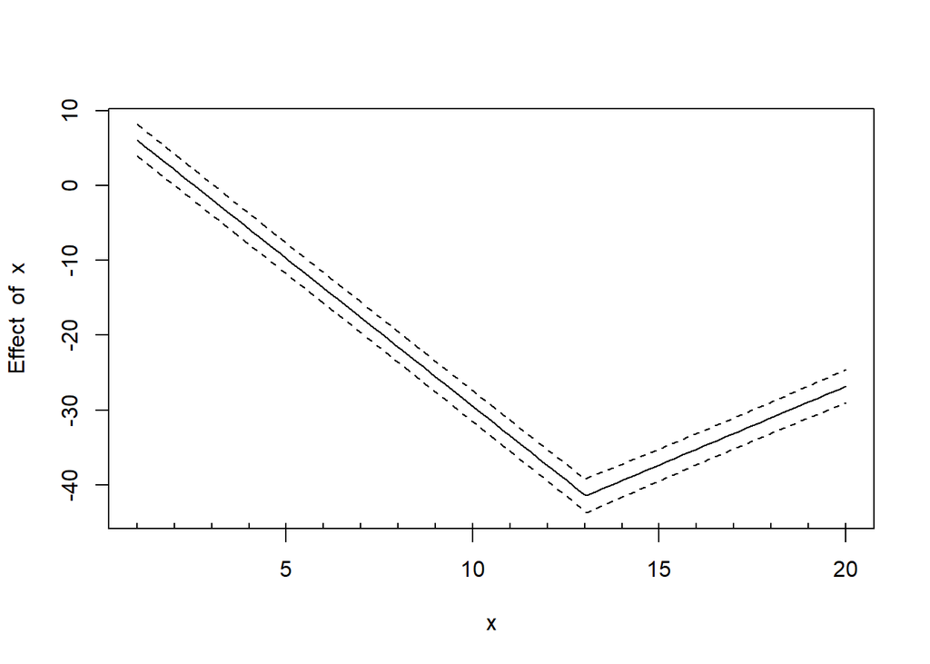

```r
plot.segmented(sm1, "x", .coef=fixef(sm1), conf.level=.95)
```

There’s probably a way to extract the values and make a nicer looking plot with ggplot2, but I’m not pursuing that.